```r
library("lubridate")
library("dplyr")
```

```r
library("tidyr")
library("ggplot2")
```

```r
restaurant_inspections <- read.csv("restaurant_inspections.csv")
rodent_inspections <- read.csv("rodent_inspections.csv")
calls <- read.csv("sandy.csv")
```

Part 1

Convert the data column into a Lubridate, and split it into month and year.

```r
rodent_inspections <- mutate(rodent_inspections, INSPECTION_DATE = mdy_hms(INSPECTION_DATE))
rodent_inspections <- mutate(rodent_inspections, INSPECTION_MONTH = as.numeric(month(INSPECTION_DATE)))
rodent_inspections <- mutate(rodent_inspections, INSPECTION_YEAR = as.numeric(year(INSPECTION_DATE)))
```

Separate the most recent 5 years, and only rows where there were active rat signs.

```r
last_5 <- filter(rodent_inspections, INSPECTION_YEAR %in% seq(2011,2015,1))
last_5_active <- filter(last_5, RESULT == "Active Rat Signs")
```

Sequence the months for plotting from 1-60, and create a table of the frequencies per month.

```r
last_5_active_sequenced <- mutate(last_5_active, SEQUENCED_MONTH = (INSPECTION_MONTH + 12*(INSPECTION_YEAR - 2011)))
freq_table <- last_5_active_sequenced %>% group_by(SEQUENCED_MONTH, RESULT) %>% summarize(count = n())
```

Plot the frequencies per month.

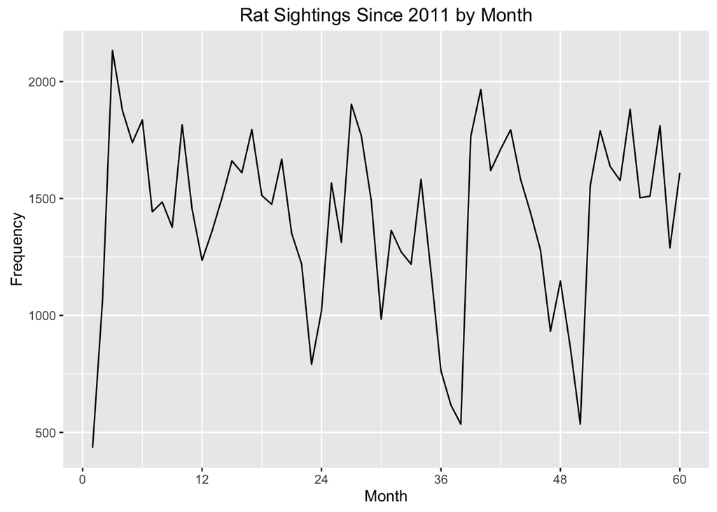

```r
freq_plot <- ggplot(freq_table, aes(freq_table$SEQUENCED_MONTH, freq_table$count)) + geom_line(group=1)
freq_plot <- freq_plot + ggtitle("Rat Sightings Since 2011 by Month") + labs(x="Month",y="Frequency")
freq_plot <- freq_plot + scale_x_continuous(breaks = seq(0,60,12))
freq_plot
```

Now, by borough.

```r
bronx <- filter(last_5_active_sequenced, BOROUGH == 'Bronx')
bronx_freq <- bronx %>% group_by(SEQUENCED_MONTH, RESULT) %>% summarize(count = n())

staten <- filter(last_5_active_sequenced, BOROUGH == 'Staten Island')
staten_freq <- staten %>% group_by(SEQUENCED_MONTH, RESULT) %>% summarize(count = n())

queens <- filter(last_5_active_sequenced, BOROUGH == 'Queens')
queens_freq <- queens %>% group_by(SEQUENCED_MONTH, RESULT) %>% summarize(count = n())

manhattan <- filter(last_5_active_sequenced, BOROUGH == 'Manhattan')
manhattan_freq <- manhattan %>% group_by(SEQUENCED_MONTH, RESULT) %>% summarize(count = n())

brooklyn <- filter(last_5_active_sequenced, BOROUGH == 'Brooklyn')
brooklyn_freq <- brooklyn %>% group_by(SEQUENCED_MONTH, RESULT) %>% summarize(count = n())
```

Bronx.

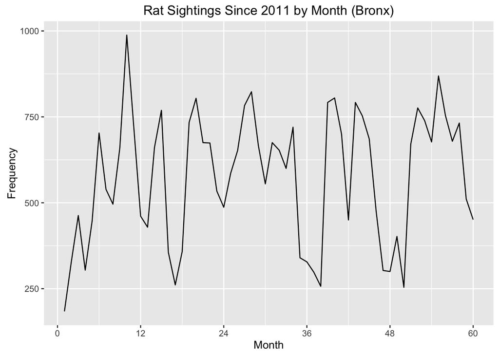

```r
freq_plot <- ggplot(bronx_freq, aes(SEQUENCED_MONTH, count)) + geom_line(group=1)
freq_plot <- freq_plot + ggtitle("Rat Sightings Since 2011 by Month (Bronx)") + labs(x="Month",y="Frequency")
freq_plot <- freq_plot + scale_x_continuous(breaks = seq(0,60,12))
freq_plot
```

Brooklyn.

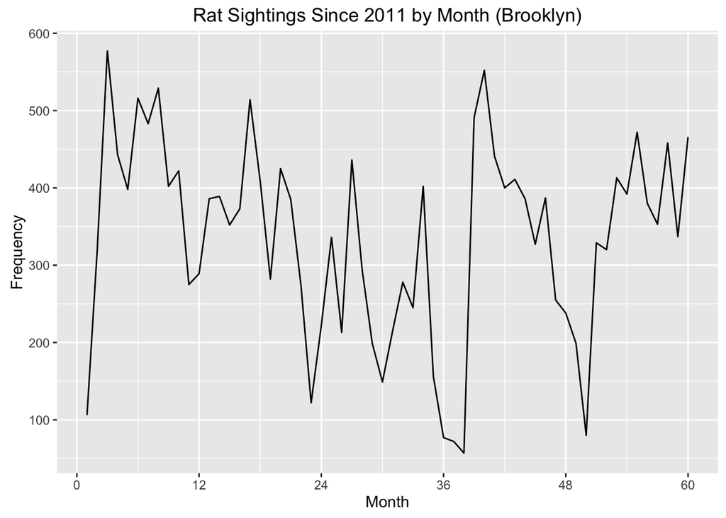

```r
freq_plot <- ggplot(brooklyn_freq, aes(SEQUENCED_MONTH, count)) + geom_line(group=1)
freq_plot <- freq_plot + ggtitle("Rat Sightings Since 2011 by Month (Brooklyn)") + labs(x="Month",y="Frequency")
freq_plot <- freq_plot + scale_x_continuous(breaks = seq(0,60,12))
freq_plot
```

Staten Island.

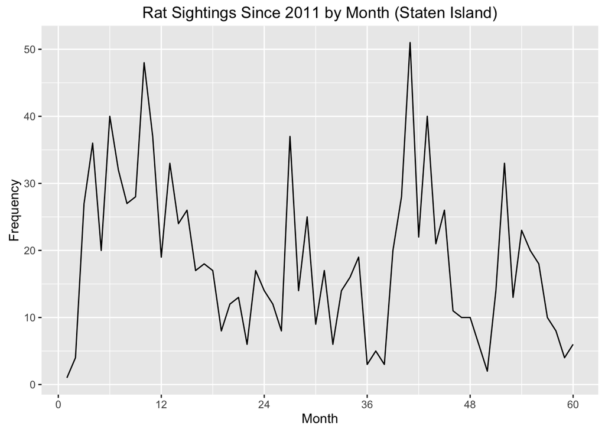

```r
freq_plot <- ggplot(staten_freq, aes(SEQUENCED_MONTH, count)) + geom_line(group=1)
freq_plot <- freq_plot + ggtitle("Rat Sightings Since 2011 by Month (Staten Island)") + labs(x="Month",y="Frequency")
freq_plot <- freq_plot + scale_x_continuous(breaks = seq(0,60,12))
freq_plot
```

Manhattan.

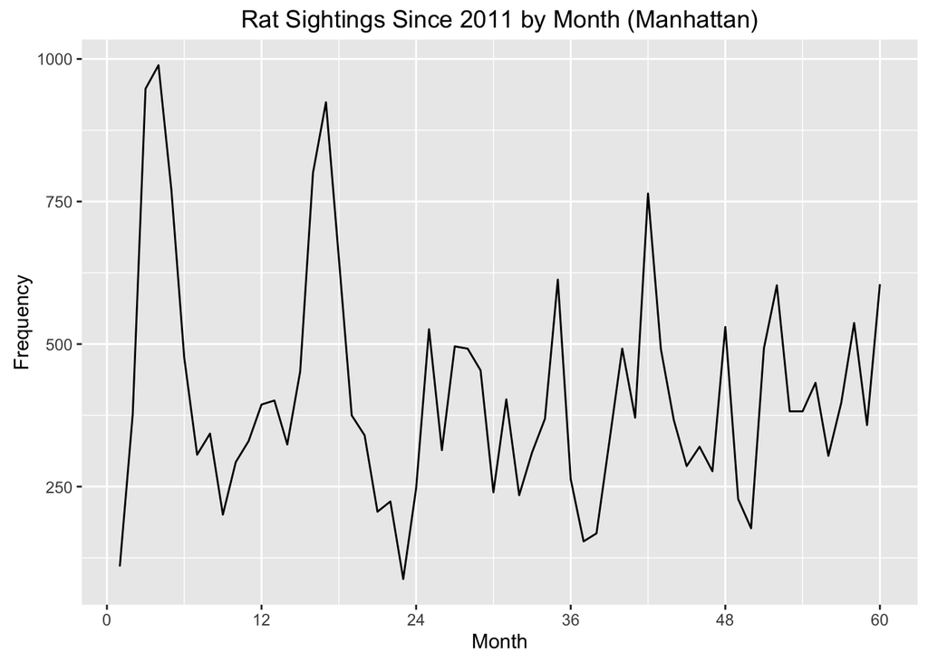

```r
freq_plot <- ggplot(manhattan_freq, aes(SEQUENCED_MONTH, count)) + geom_line(group=1)
freq_plot <- freq_plot + ggtitle("Rat Sightings Since 2011 by Month (Manhattan)") + labs(x="Month",y="Frequency")
freq_plot <- freq_plot + scale_x_continuous(breaks = seq(0,60,12))
freq_plot
```

Queens.

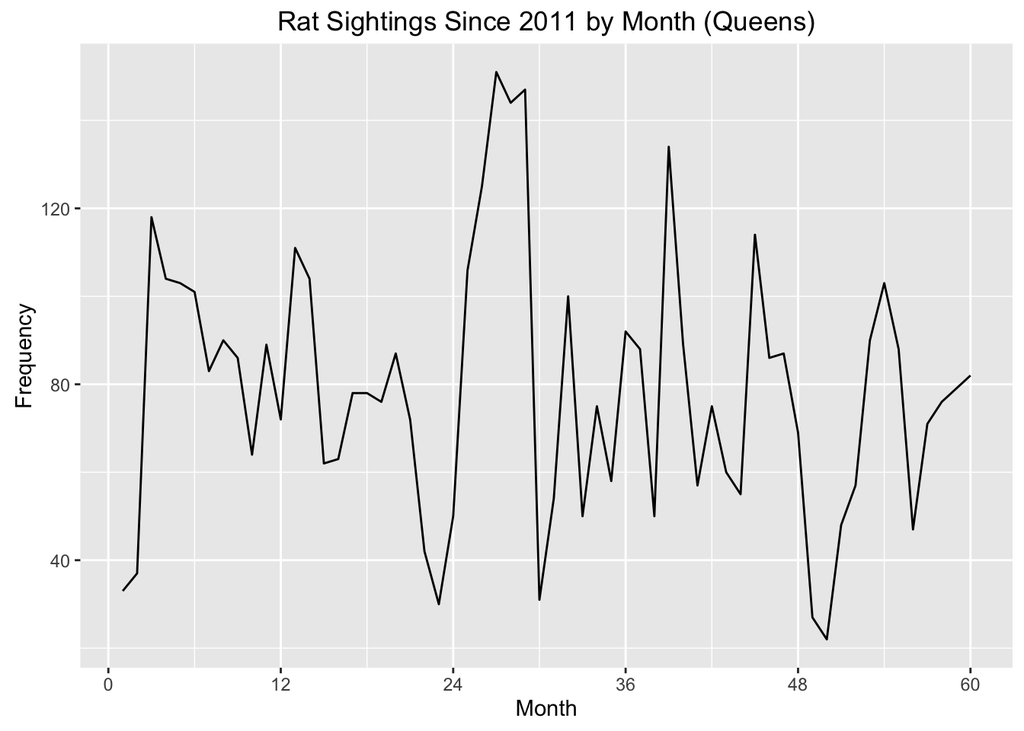

```r
freq_plot <- ggplot(queens_freq, aes(SEQUENCED_MONTH, count)) + geom_line(group=1)
freq_plot <- freq_plot + ggtitle("Rat Sightings Since 2011 by Month (Queens)") + labs(x="Month",y="Frequency")
freq_plot <- freq_plot + scale_x_continuous(breaks = seq(0,60,12))
freq_plot
```

Create a dataframe of the last 5 years, sequenced by month (not only active rat signs cells).

```r
last_5_sequenced <- mutate(last_5, SEQUENCED_MONTH = (INSPECTION_MONTH + 12*(INSPECTION_YEAR - 2011)))
```

Group the dataframe by sequenced month, and create columns for the number of cells per, and the total.

```r
grouped <- group_by(last_5_sequenced, BOROUGH, SEQUENCED_MONTH,RESULT)
grouped <- summarize(grouped,count=n())
grouped <- mutate(grouped, SUM = sum(count))
```

For each cell in the grouped dataframe, create a ratio of the count of active rat sightings to the total number of inspections.

```r
for (i in seq(1,nrow(grouped),1)) {

  if (grouped[i, 'RESULT'] == 'Active Rat Signs') {
    grouped[i, 'EFFICIENCY'] = grouped[i, 'count'] / grouped[i, 'SUM']
  }

}
```

Extract all of the efficiency values, and plot them per sequenced month.

Bronx.

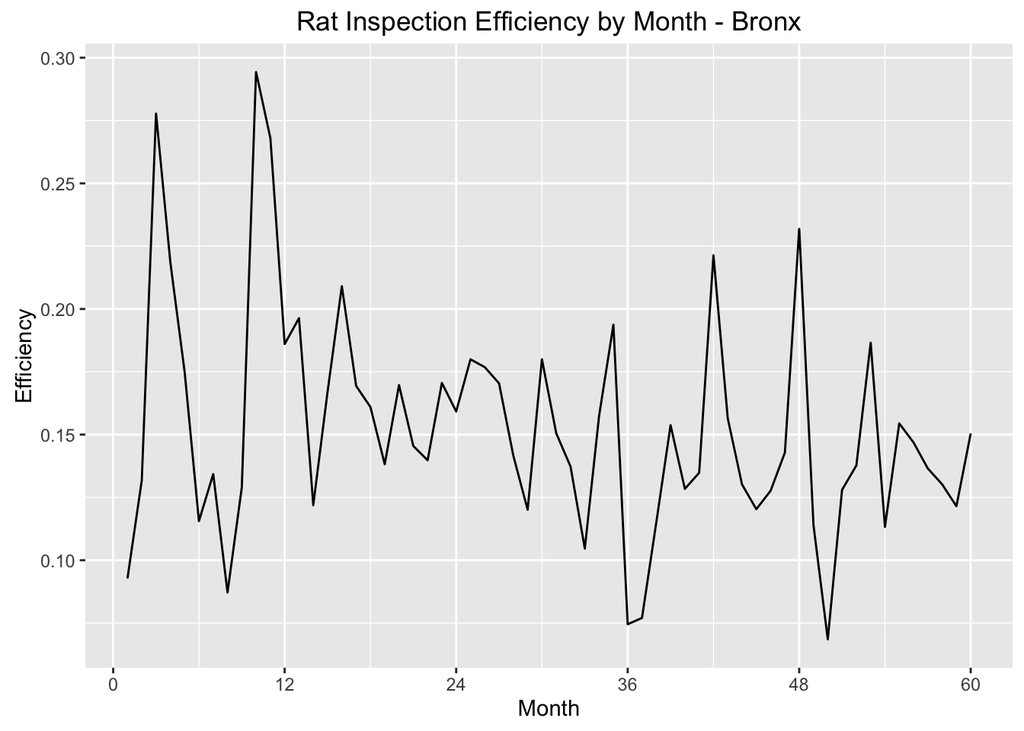

```r
perMonth <- filter(grouped, !is.na(EFFICIENCY), BOROUGH == "Bronx")

effPlot <- ggplot(perMonth, aes(SEQUENCED_MONTH, EFFICIENCY)) + geom_line(group=1)
last_plot() + ggtitle("Rat Inspection Efficiency by Month - Bronx") + labs(x="Month", y="Efficiency") + scale_x_continuous(breaks = seq(0,60,12))
```

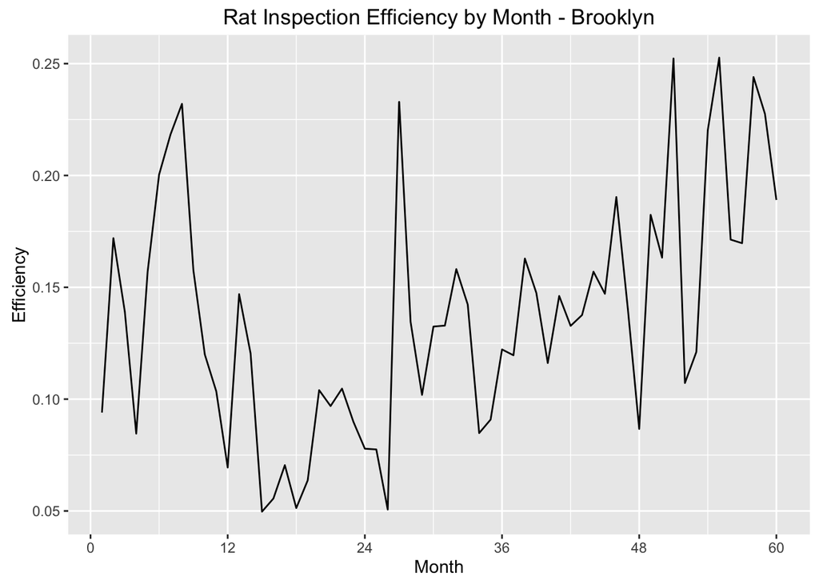

```r
perMonth <- filter(grouped, !is.na(EFFICIENCY), BOROUGH == "Brooklyn")

effPlot <- ggplot(perMonth, aes(SEQUENCED_MONTH, EFFICIENCY)) + geom_line(group=1)
last_plot() + ggtitle("Rat Inspection Efficiency by Month - Brooklyn") + labs(x="Month", y="Efficiency") + scale_x_continuous(breaks = seq(0,60,12))
```

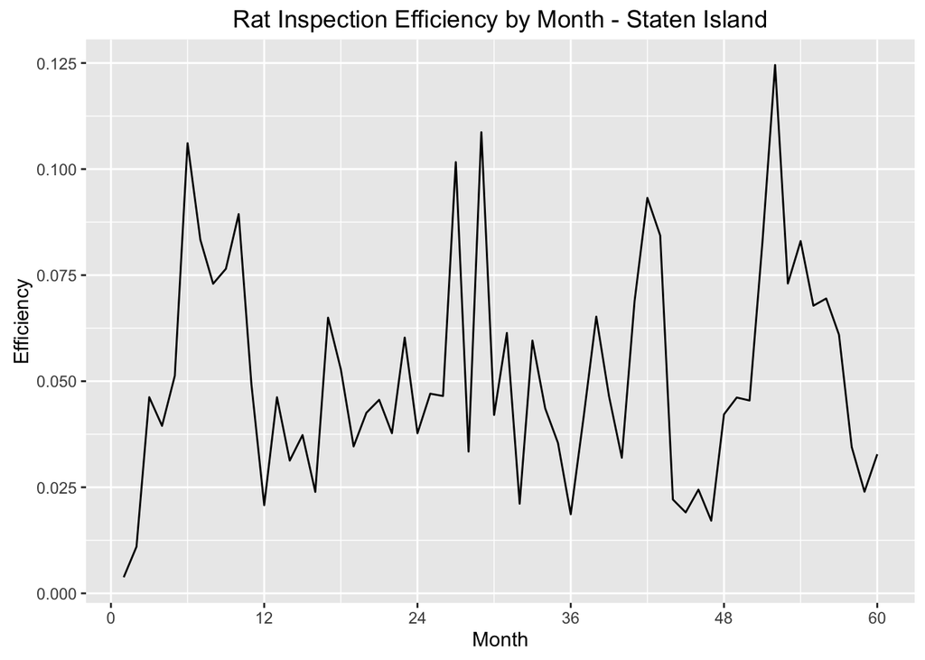

```r
perMonth <- filter(grouped, !is.na(EFFICIENCY), BOROUGH == "Staten Island")

effPlot <- ggplot(perMonth, aes(SEQUENCED_MONTH, EFFICIENCY)) + geom_line(group=1)
last_plot() + ggtitle("Rat Inspection Efficiency by Month - Staten Island") + labs(x="Month", y="Efficiency") + scale_x_continuous(breaks = seq(0,60,12))
```

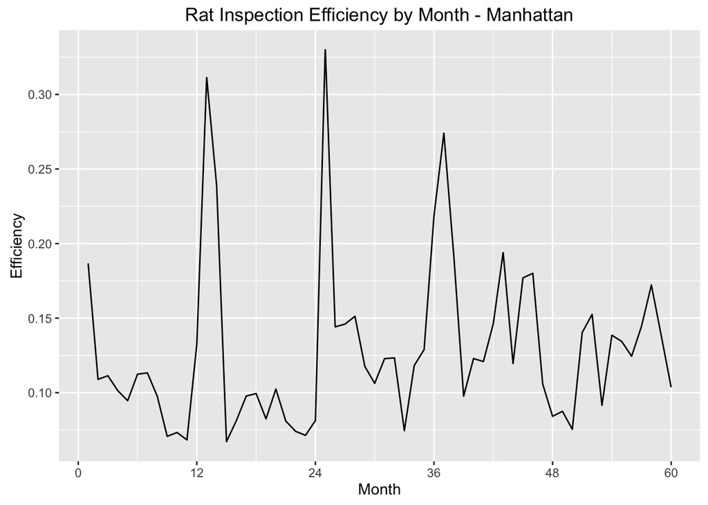

```r
perMonth <- filter(grouped, !is.na(EFFICIENCY), BOROUGH == "Manhattan")

effPlot <- ggplot(perMonth, aes(SEQUENCED_MONTH, EFFICIENCY)) + geom_line(group=1)
last_plot() + ggtitle("Rat Inspection Efficiency by Month - Manhattan") + labs(x="Month", y="Efficiency") + scale_x_continuous(breaks = seq(0,60,12))
```

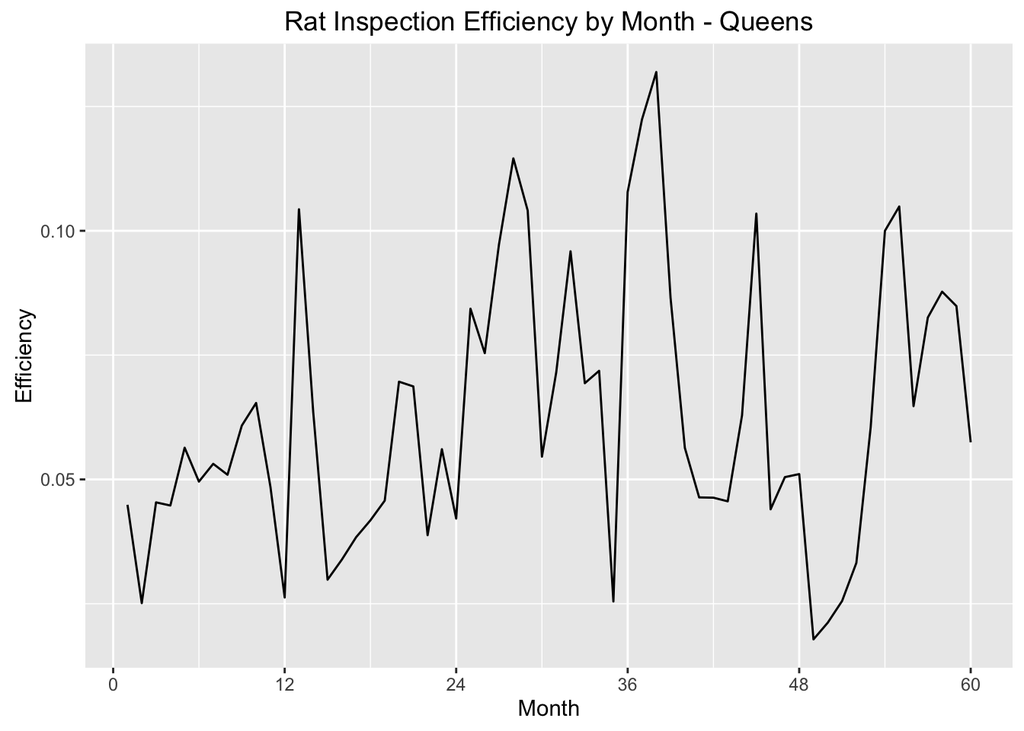

```r
perMonth <- filter(grouped, !is.na(EFFICIENCY), BOROUGH == "Queens")

effPlot <- ggplot(perMonth, aes(SEQUENCED_MONTH, EFFICIENCY)) + geom_line(group=1)
last_plot() + ggtitle("Rat Inspection Efficiency by Month - Queens") + labs(x="Month", y="Efficiency") + scale_x_continuous(breaks = seq(0,60,12))
```

Group the active-filtered dataframe by zip code, summarize by count of cells per, and arrange descending.

```r
groupedByZip <- last_5_active %>% group_by(ZIP_CODE,RESULT) %>% summarize(count=n()) %>% arrange(desc(count))
groupedByZip
```

```
## Source: local data frame [177 x 3]
## Groups: ZIP_CODE [177]
##
##    ZIP_CODE           RESULT count
##       <int>           <fctr> <int>
## 1     10457 Active Rat Signs  5563
## 2     10458 Active Rat Signs  5270
## 3     10456 Active Rat Signs  4098
## 4     10468 Active Rat Signs  3335
## 5     11221 Active Rat Signs  3102
## 6     10453 Active Rat Signs  2998
## 7     10452 Active Rat Signs  2364
## 8     10467 Active Rat Signs  2145
## 9     11237 Active Rat Signs  2111
## 10    11206 Active Rat Signs  1835
## # ... with 167 more rows
```

Part 2

Find the top 20 zipcodes pre sandy (2012).

```r
active <- filter(rodent_inspections, RESULT == 'Active Rat Signs')
pre_sandy <- active %>% filter(INSPECTION_YEAR < 2012 & INSPECTION_YEAR >= 2011) %>% group_by(ZIP_CODE, RESULT) %>% summarize(count = n()) %>% arrange(desc(count))
head(pre_sandy, n=20)
```

```
## Source: local data frame [20 x 3]
## Groups: ZIP_CODE [20]
##
##    ZIP_CODE           RESULT count
##       <int>           <fctr> <int>
## 1     10457 Active Rat Signs  1028
## 2     10456 Active Rat Signs   955
## 3     10458 Active Rat Signs   890
## 4     11221 Active Rat Signs   647
## 5     10453 Active Rat Signs   595
## 6     11216 Active Rat Signs   534
## 7     10468 Active Rat Signs   509
## 8     11206 Active Rat Signs   428
## 9     11237 Active Rat Signs   413
## 10    10002 Active Rat Signs   407
## 11    11238 Active Rat Signs   383
## 12    10031 Active Rat Signs   367
## 13    10009 Active Rat Signs   365
## 14    10472 Active Rat Signs   363
## 15    11211 Active Rat Signs   363
## 16    11217 Active Rat Signs   356
## 17    10032 Active Rat Signs   346
## 18    10459 Active Rat Signs   337
## 19    10013 Active Rat Signs   302
## 20    10467 Active Rat Signs   277
```

Find the top 20 zipcodes post sandy.

```r
post_sandy <- active %>% filter(INSPECTION_YEAR >= 2012 & INSPECTION_YEAR < 2016) %>% group_by(ZIP_CODE, RESULT) %>% summarize(count = n()) %>% arrange(desc(count))
head(post_sandy, n=20)
```

```
## Source: local data frame [20 x 3]
## Groups: ZIP_CODE [20]
##
##    ZIP_CODE           RESULT count
##       <int>           <fctr> <int>
## 1     10457 Active Rat Signs  4535
## 2     10458 Active Rat Signs  4380
## 3     10456 Active Rat Signs  3143
## 4     10468 Active Rat Signs  2826
## 5     11221 Active Rat Signs  2455
## 6     10453 Active Rat Signs  2403
## 7     10452 Active Rat Signs  2088
## 8     10467 Active Rat Signs  1868
## 9     11237 Active Rat Signs  1698
## 10    11206 Active Rat Signs  1407
## 11    10460 Active Rat Signs  1383
## 12    10009 Active Rat Signs  1364
## 13    10002 Active Rat Signs  1345
## 14    11216 Active Rat Signs  1299
## 15    10032 Active Rat Signs  1242
## 16    10025 Active Rat Signs  1185
## 17    10027 Active Rat Signs  1170
## 18    10029 Active Rat Signs  1161
## 19    10033 Active Rat Signs  1136
## 20    10031 Active Rat Signs  1073
```

Find the top 20 zipcodes of sandy calls about rat sightings.

```r
rat_calls <- calls %>% filter(Descriptor == 'Rat Sighting') %>% group_by(Incident.Zip, Descriptor) %>% summarize(count = n()) %>% arrange(desc(count))
rat_calls
```

```
## Source: local data frame [79 x 3]
## Groups: Incident.Zip [79]
##
##    Incident.Zip   Descriptor count
##          <fctr>       <fctr> <int>
## 1         10025 Rat Sighting    14
## 2         10456 Rat Sighting     7
## 3         11207 Rat Sighting     7
## 4         11237 Rat Sighting     6
## 5         11221 Rat Sighting     5
## 6         10027 Rat Sighting     4
## 7         10453 Rat Sighting     4
## 8         10458 Rat Sighting     4
## 9         10467 Rat Sighting     4
## 10        11222 Rat Sighting     4
## # ... with 69 more rows
```

Something is wrong with the calls list (I think), but based on the first two, there was NOT significant displacement in the rat population. The top 10 zip codes are basically the same, almost in the same order.

Part 3

Make a new binary column in the restaurant_inspections dataframe that contains whether there was a rat related violation (1 = yes) based on violation codes.

```r
violation_codes <- c("04L", "04K", "08A")
restaurant_inspections <- mutate(restaurant_inspections, RatViolation = ifelse(VIOLATION.CODE %in% violation_codes, 1, 0))
```

Remove errant zipcodes by grouping the data by zipcode and comparing to a list of nons.

```r
freqs <- data.frame(table(last_5_sequenced$ZIP_CODE, last_5_sequenced$SEQUENCED_MONTH, last_5_sequenced$RESULT))
colnames(freqs) <- c("Zip", "Month", "Result", "Frequency")
freqs_df <- spread(freqs, Result, Frequency)
freqs_df[,3] <- NULL
```

Filter out non-zips.

```r
non_zips <- c(0,1,10,111111,9999999)
freqs_df <- filter(freqs_df, !(Zip %in% non_zips))
```

Calculate efficiencies.

```r
freqs_df$Total <- rowSums(freqs_df[,seq(3,ncol(freqs_df)-1)])
freqs_df$Efficiency <- freqs_df$`Active Rat Signs` / freqs_df$Total
```

Filter out NA.

```r
freqs_df[is.na(freqs_df)] <- 0
```

Now merge the grouped dataset with the restaurant_inspections dataframe.

First we’ll set up the columns in the restaurant_inspection dataframe as in the rodent_inspection one - with months sequenced from 1-60. We need to do this so we can merge them on mutual columns.

```r
restaurant_inspections_new <- mutate(restaurant_inspections, INSPECTION.DATE = mdy(INSPECTION.DATE))
restaurant_inspections_new <- mutate(restaurant_inspections_new, INSPECTION_MONTH = as.numeric(month(INSPECTION.DATE)))
restaurant_inspections_new <- mutate(restaurant_inspections_new, INSPECTION_YEAR = as.numeric(year(INSPECTION.DATE)))

last_5_restaurants <- filter(restaurant_inspections_new, INSPECTION_YEAR %in% seq(2011,2016,1))
last_5_restaurants_sequenced <- mutate(last_5_restaurants, SEQUENCED_MONTH = (INSPECTION_MONTH + 12*(INSPECTION_YEAR - 2011)))
```

Finally, we’ll merge the two dataframes on zip codes and sequenced months.

```r
names(last_5_restaurants_sequenced)[6] <- "Zip"
names(last_5_restaurants_sequenced)[ncol(last_5_restaurants_sequenced)] <- "Month"
merged <- merge(last_5_restaurants_sequenced, freqs_df, by=c("Zip","Month"))
```

Regression:

Reset the year and month as factor variables.

```r
merged$INSPECTION_YEAR.f <- as.factor(merged$INSPECTION_YEAR)
merged$INSPECTION_MONTH.f <- as.factor(merged$INSPECTION_MONTH)
merged$Month.f <- as.factor(merged$Month)
```

Select the columns that are important.

```r
merged_selected <- select(merged, Zip, Month.f, INSPECTION_MONTH.f, INSPECTION_YEAR.f, DBA, RatViolation, Efficiency)
```

Run a logistic regression.

```r
reg <- glm(data=merged_selected, RatViolation ~ Efficiency + INSPECTION_MONTH.f + INSPECTION_YEAR.f, family = "binomial")
```

```r
summary(reg)
```

```
##
## Call:
## glm(formula = RatViolation ~ Efficiency + INSPECTION_MONTH.f +
##     INSPECTION_YEAR.f, family = "binomial", data = merged_selected)
##
## Deviance Residuals:
##     Min       1Q   Median       3Q      Max
## -0.6522  -0.6327  -0.6078  -0.5825   1.9528
##
## Coefficients:
##                        Estimate Std. Error z value Pr(>|z|)
## (Intercept)           -1.476849   0.206360  -7.157 8.27e-13 ***
## Efficiency            -0.008813   0.022568  -0.391 0.696156
## INSPECTION_MONTH.f2   -0.027589   0.021153  -1.304 0.192160
## INSPECTION_MONTH.f3   -0.097144   0.020496  -4.740 2.14e-06 ***
## INSPECTION_MONTH.f4   -0.144680   0.020228  -7.153 8.51e-13 ***
## INSPECTION_MONTH.f5   -0.224826   0.020480 -10.978  < 2e-16 ***
## INSPECTION_MONTH.f6   -0.203091   0.020539  -9.888  < 2e-16 ***
## INSPECTION_MONTH.f7   -0.175705   0.021205  -8.286  < 2e-16 ***
## INSPECTION_MONTH.f8   -0.105870   0.020799  -5.090 3.58e-07 ***
## INSPECTION_MONTH.f9   -0.075931   0.020522  -3.700 0.000216 ***
## INSPECTION_MONTH.f10  -0.037330   0.020094  -1.858 0.063207 .
## INSPECTION_MONTH.f11   0.009202   0.020994   0.438 0.661144
## INSPECTION_MONTH.f12   0.006024   0.020198   0.298 0.765492
## INSPECTION_YEAR.f2012 -0.022235   0.206232  -0.108 0.914141
## INSPECTION_YEAR.f2013 -0.035387   0.205823  -0.172 0.863493
## INSPECTION_YEAR.f2014  0.028098   0.205791   0.137 0.891396
## INSPECTION_YEAR.f2015  0.026271   0.205801   0.128 0.898424
## ---
## Signif. codes:  0 '***' 0.001 '**' 0.01 '*' 0.05 '.' 0.1 ' ' 1
##
## (Dispersion parameter for binomial family taken to be 1)
##
##     Null deviance: 402955  on 437434  degrees of freedom
## Residual deviance: 402504  on 437418  degrees of freedom
## AIC: 402538
##
## Number of Fisher Scoring iterations: 4
```

```r
merged_selected$prob <- predict(reg, type='response')
```